# IODS project

# Week 6: Dimension reduction

## Excercise 5: Analysis exercises

I starter the exercise loading the “human” data set into R and exploring the data structure and dimensions. Exploring the data structure revealed that the data has 155 observations and 8 variables. Each observation represents a country and the variables describe gender ratios in health, education and economy related indexes.

```r
human <- read.csv("data/human.csv", header = TRUE, row.names = 1)

str(human)
```

```
## 'data.frame':    155 obs. of  8 variables:
##  $ Edu2.FM  : num  1.007 0.997 0.983 0.989 0.969 ...
##  $ Labo.FM  : num  0.891 0.819 0.825 0.884 0.829 ...
##  $ Life.Exp : num  81.6 82.4 83 80.2 81.6 80.9 80.9 79.1 82 81.8 ...
##  $ Edu.Exp  : num  17.5 20.2 15.8 18.7 17.9 16.5 18.6 16.5 15.9 19.2 ...
##  $ GNI      : int  64992 42261 56431 44025 45435 43919 39568 52947 42155 32689 ...
##  $ Mat.Mor  : int  4 6 6 5 6 7 9 28 11 8 ...
##  $ Ado.Birth: num  7.8 12.1 1.9 5.1 6.2 3.8 8.2 31 14.5 25.3 ...
##  $ Parli.F  : num  39.6 30.5 28.5 38 36.9 36.9 19.9 19.4 28.2 31.4 ...
```

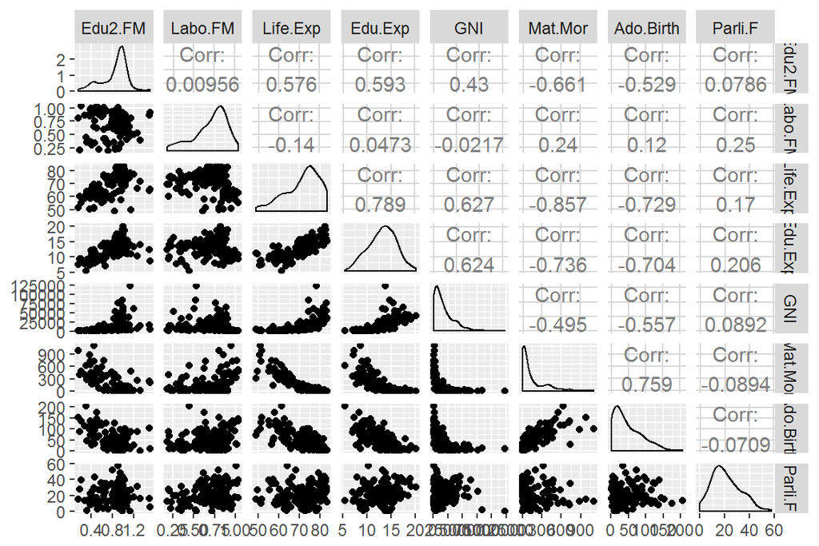

```r
library(GGally)

ggpairs(human)
```

Given that a correltion matrix of eight variables may be hard to grasp with brief inspection, I plotted a graphical version of it in which the correltions are represented with colored circles. The corrplot matrix revealed high positive correlations between maternal mortality and adolescent bitrh rate and expected duration of education and live expectancy. High negtive correlations were found between gender ratio of eductaion, maternal mortality and adolescent birth rate as well as life/education expectancy, maternal mortality and adolescent birth rate.

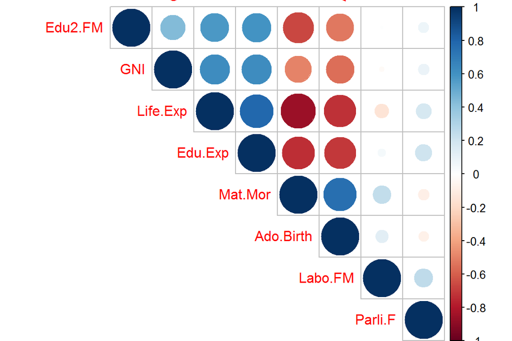

```r
library(corrplot)
library(dplyr)

# plotting the correlation matrix
cor(human) %>% corrplot(, type="upper", order="hclust")
```

```r
pca_human <- prcomp(human)
summary(pca_human)
```

```
## Importance of components:
##                              PC1      PC2   PC3   PC4   PC5   PC6    PC7
## Standard deviation     1.854e+04 185.5219 25.19 11.45 3.766 1.566 0.1912
## Proportion of Variance 9.999e-01   0.0001  0.00  0.00 0.000 0.000 0.0000
## Cumulative Proportion  9.999e-01   1.0000  1.00  1.00 1.000 1.000 1.0000
##                           PC8
## Standard deviation     0.1591
## Proportion of Variance 0.0000
## Cumulative Proportion  1.0000
```

Plotting the biplot concretized this issue even further. The scale of GNI was so much bigger comapred to any other variable that the relative distances between the observations in terms of all variables were not visible.

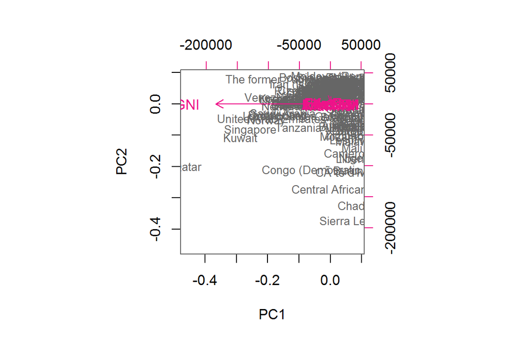

```r
biplot(pca_human, choices = 1:2, cex = c(0.8, 1), col = c("grey40", "deeppink2"))
```

Next I scaled the human data and run the PCA agan on the standardized set. As a result of standardising, the proportion of explained variance was changed. The results above indicate that 53.6 5 of the variance in the data is explained by the first (PC1) component, 16.2 % by the second component, and 9.6 % by the third component.

```r
humanz <- scale(human)


pca_humanz <- prcomp(humanz)

summary(pca_humanz)
```

```
## Importance of components:
##                           PC1    PC2     PC3     PC4     PC5     PC6
## Standard deviation     2.0708 1.1397 0.87505 0.77886 0.66196 0.53631
## Proportion of Variance 0.5361 0.1624 0.09571 0.07583 0.05477 0.03595
## Cumulative Proportion  0.5361 0.6984 0.79413 0.86996 0.92473 0.96069
##                            PC7     PC8
## Standard deviation     0.45900 0.32224
## Proportion of Variance 0.02634 0.01298
## Cumulative Proportion  0.98702 1.00000
```

Printing out the biplot revealed that the original variables could be converted into a set of two uncorrelated dimensions. The first dimension, based on the PC1, is best defined by, GNI Life.Exp, Edu.Exp, Edu2.FM, Ado.Birth, and Mat.Mor whereas the second dimension, ortogonal to the first one and best defined by PC2, reflects the set of Parli.F and Labo.FM. The figure shows that variables related to the first dimensions are highly correlated (both negatively and positively) and that the variables of the second dimensions do not correlate with those of the first dimension.

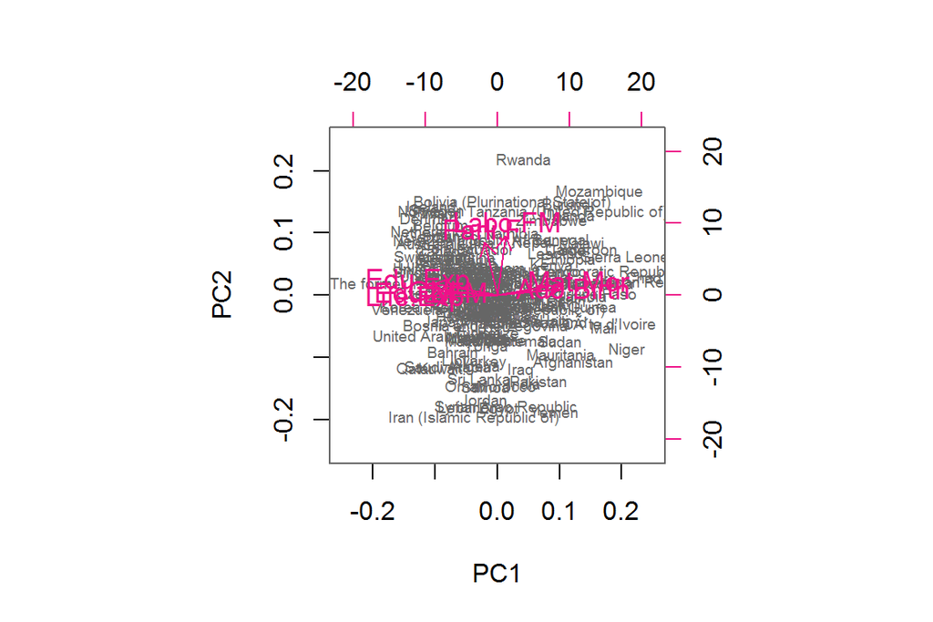

Figure 1: The scoring of 155 countries and loading of original variables on the first two principal components. The left and bottom axes are showing [standardized] principal component scores and the top and right axes are showing the loadings.

## It’s tea time!

Finally, I loaded a new “tea” data set and used Multible correspondence analysis (MCA) on the data set. The tea data consists of 35 factorial variables, 1 continuos variable (age) and 300 observations describing tea user’s preferences and habits.

```r
library(FactoMineR)

# loading the tea data
data("tea")
str(tea)
```

```
## 'data.frame':    300 obs. of  36 variables:
##  $ breakfast       : Factor w/ 2 levels "breakfast","Not.breakfast": 1 1 2 2 1 2 1 2 1 1 ...
##  $ tea.time        : Factor w/ 2 levels "Not.tea time",..: 1 1 2 1 1 1 2 2 2 1 ...
##  $ evening         : Factor w/ 2 levels "evening","Not.evening": 2 2 1 2 1 2 2 1 2 1 ...
##  $ lunch           : Factor w/ 2 levels "lunch","Not.lunch": 2 2 2 2 2 2 2 2 2 2 ...
##  $ dinner          : Factor w/ 2 levels "dinner","Not.dinner": 2 2 1 1 2 1 2 2 2 2 ...
##  $ always          : Factor w/ 2 levels "always","Not.always": 2 2 2 2 1 2 2 2 2 2 ...
##  $ home            : Factor w/ 2 levels "home","Not.home": 1 1 1 1 1 1 1 1 1 1 ...
##  $ work            : Factor w/ 2 levels "Not.work","work": 1 1 2 1 1 1 1 1 1 1 ...
##  $ tearoom         : Factor w/ 2 levels "Not.tearoom",..: 1 1 1 1 1 1 1 1 1 2 ...
##  $ friends         : Factor w/ 2 levels "friends","Not.friends": 2 2 1 2 2 2 1 2 2 2 ...
##  $ resto           : Factor w/ 2 levels "Not.resto","resto": 1 1 2 1 1 1 1 1 1 1 ...
##  $ pub             : Factor w/ 2 levels "Not.pub","pub": 1 1 1 1 1 1 1 1 1 1 ...
##  $ Tea             : Factor w/ 3 levels "black","Earl Grey",..: 1 1 2 2 2 2 2 1 2 1 ...
##  $ How             : Factor w/ 4 levels "alone","lemon",..: 1 3 1 1 1 1 1 3 3 1 ...
```

[output cut: 22 more lines]

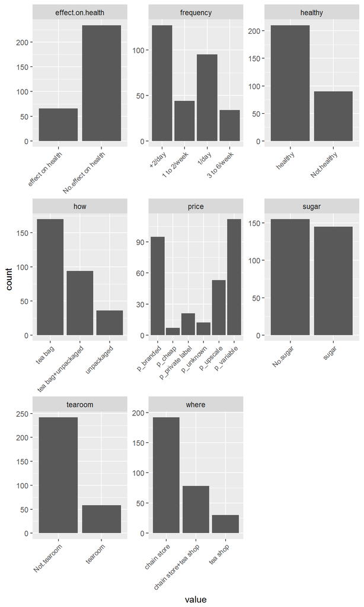

```r
library(ggplot2)
library(tidyr)


tea_time <- dplyr::select(tea, one_of(c("how", "effect.on.health", "where", "healthy", "price", "tearoom", "frequency", "sugar")))

gather(tea_time) %>% ggplot(aes(value)) + facet_wrap("key", scales = "free") + geom_bar() + theme(axis.text.x = element_text(angle = 45, hjust = 1, size = 8))
```

This smaller data set was used to run a multible correspondence analysis (MCA). MCA allows researchers to analyze the systematic patterns of variations within a data that consists of categorical variables.

Printing out the MCA summary revealed that the first dimension explained 14.13 % of the variation whereas the second dimension accounted for 11.1% of the variation. The second table shows data of the first 10 individuals in relation to the dimensions, the third table shows loadings of the variable categories, and the last table shows the eta squared values between the variables and dimensions. The first dimensions seems to reflect preferences related to tea quality and whereas the third one is associated to health. Meaning of the second dimension is less clear as it seems to capture variance of both health and quality related variables.

```r
# running the MCA
mca <- MCA(tea_time, graph = FALSE)

# printing out the model statistics
summary(mca)
```

```
##
## Call:
## MCA(X = tea_time, graph = FALSE)
##
##
## Eigenvalues
##                        Dim.1   Dim.2   Dim.3   Dim.4   Dim.5   Dim.6
## Variance               0.283   0.222   0.180   0.140   0.135   0.134
## % of var.             14.128  11.097   8.994   6.981   6.748   6.690
## Cumulative % of var.  14.128  25.226  34.220  41.201  47.949  54.639
##                        Dim.7   Dim.8   Dim.9  Dim.10  Dim.11  Dim.12
## Variance               0.123   0.120   0.119   0.106   0.094   0.090
## % of var.              6.156   6.001   5.966   5.306   4.678   4.525
## Cumulative % of var.  60.794  66.795  72.762  78.068  82.746  87.270
##                       Dim.13  Dim.14  Dim.15  Dim.16
## Variance               0.081   0.066   0.062   0.045
## % of var.              4.032   3.315   3.112   2.271
## Cumulative % of var.  91.302  94.617  97.729 100.000
##
## Individuals (the 10 first)
##                         Dim.1    ctr   cos2    Dim.2    ctr   cos2
## 1                    | -0.751  0.666  0.153 |  0.188  0.053  0.010 |
## 2                    | -0.349  0.143  0.138 | -0.200  0.060  0.045 |
## 3                    | -0.172  0.035  0.038 | -0.295  0.131  0.112 |
## 4                    | -0.461  0.250  0.236 | -0.112  0.019  0.014 |
## 5                    | -0.143  0.024  0.020 | -0.124  0.023  0.015 |
## 6                    | -0.601  0.426  0.155 |  0.020  0.001  0.000 |
## 7                    | -0.202  0.048  0.026 | -0.204  0.062  0.026 |
## 8                    | -0.330  0.129  0.081 |  0.009  0.000  0.000 |
## 9                    |  0.752  0.668  0.305 | -0.229  0.079  0.028 |
## 10                   |  1.028  1.248  0.501 | -0.550  0.454  0.143 |
##                       Dim.3    ctr   cos2
## 1                    -0.189  0.066  0.010 |
## 2                    -0.255  0.121  0.074 |
## 3                    -0.277  0.142  0.098 |
## 4                    -0.127  0.030  0.018 |
## 5                     0.172  0.055  0.029 |
## 6                    -0.243  0.109  0.025 |
## 7                     0.102  0.019  0.007 |
## 8                     0.056  0.006  0.002 |
```

[output cut: 22 more lines]

```
## chain store+tea shop   0.295  -9.386 |   0.268   1.295   0.025   2.744 |
## tea shop               0.386  10.750 |  -0.824   4.720   0.075  -4.750 |
## healthy                0.088  -5.124 |  -0.457  10.146   0.487 -12.063 |
## Not.healthy            0.088   5.124 |   1.066  23.675   0.487  12.063 |
##
## Categorical variables (eta2)
##                        Dim.1 Dim.2 Dim.3
## how                  | 0.577 0.491 0.057 |
## effect.on.health     | 0.008 0.101 0.280 |
## where                | 0.667 0.570 0.087 |
## healthy              | 0.003 0.088 0.487 |
## price                | 0.563 0.305 0.181 |
## tearoom              | 0.262 0.049 0.036 |
## frequency            | 0.124 0.144 0.265 |
## sugar                | 0.057 0.027 0.047 |
```

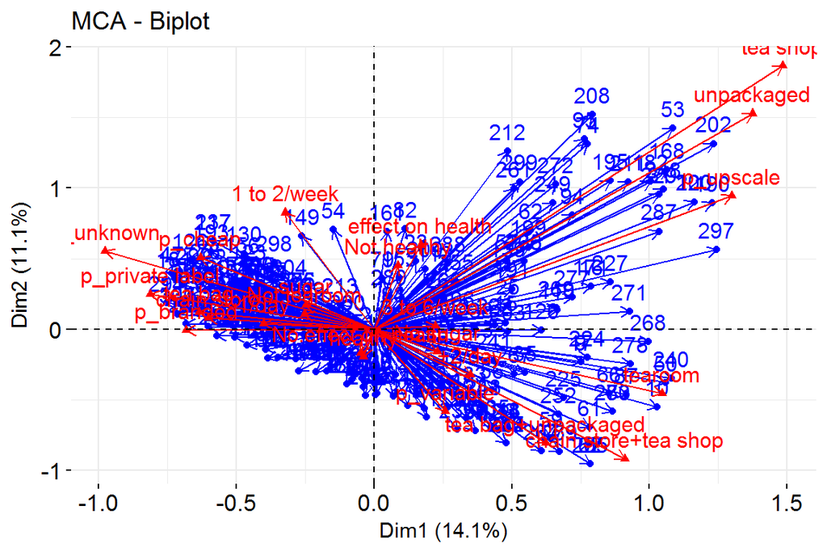

```r
library("devtools")
library("factoextra")

fviz_mca_biplot(mca, axes = c(1, 2), geom = c("point", "text", "arrow"),
  label = "all")
```